# SBC Data Exploration

Mary Fisher

February 28, 2020

A quick data exploration for correlation between variables.

Research Questions:

1. How does fish / invertebrate community abundance and diversity vary according to giant kelp size and abundance?
2. How are oceanographic conditions and herbivore abundance correlated with giant kelp size and abundance?

This script was rerun on Mar 5, 2020, for observations at the site (instead of transect) level.

## Data

For question 1, I need the kelp, fish, and invertebrate data.

```
##  [1] "year"              "month"             "site"
##  [4] "mapy_mean_density" "mapy_mean_count"   "mapy_mean_fronds"
##  [7] "mapy_max_fronds"   "mapy_mean_hld"     "mapy_max_hld"
## [10] "abundance"         "div.shannon"       "div.simpson"
## [13] "order.div.shannon" "order.div.simpson" "order.mrichness"
## [16] "order.richness"    "sp.mrichness"      "sp.richness"
```

For question 2, I need the kelp, oceanographic, and urchin abundance data.

```
##   year month site mapy_mean_density mapy_mean_count mapy_mean_fronds
## 1 2001     8 ABUR        0.16250000       13.000000       42.6153846
## 2 2001     8 AHND        0.08750000        7.000000        5.3571429
## 3 2001     8 AQUE        0.11000000        8.800000        6.8409091
## 4 2001     8 BULL        0.05416667        4.333333        0.9230769
## 5 2001     8 CARP        0.08906250        7.125000        5.0175439
## 6 2001     8 GOLB        0.06250000        5.000000      138.4000000
##   mapy_max_fronds mapy_mean_hld mapy_max_hld franciscanus.abundance
## 1             247      53.72727          155                   0.00
## 2              20      55.55556          180                   0.00
## 3              52      11.87879           30                   4.00
## 4               4      26.33333           33                   1.00
## 5              29      18.25000           29                   7.25
## 6             315     116.25000          167                   0.00
##   purpuratus.abundance urchin.abundance
## 1              0.00000          0.00000
## 2             19.50000         19.50000
## 3             47.60000         51.60000
## 4             59.33333         60.33333
## 5            262.00000        269.25000
## 6             11.00000         11.00000
```

```
##   year month site mapy_mean_density mapy_mean_count mapy_mean_fronds
## 1 2001     8 ABUR        0.16250000       13.000000       42.6153846
## 2 2001     8 AHND        0.08750000        7.000000        5.3571429
## 3 2001     8 AQUE        0.11000000        8.800000        6.8409091
## 4 2001     8 BULL        0.05416667        4.333333        0.9230769
## 5 2001     8 CARP        0.08906250        7.125000        5.0175439
## 6 2001     8 GOLB        0.06250000        5.000000      138.4000000
##   mapy_max_fronds mapy_mean_hld mapy_max_hld max_ammonia max_no2_no3 max_po4
## 1             247      53.72727          155          NA          NA      NA
## 2              20      55.55556          180          NA          NA      NA
## 3              52      11.87879           30          NA        1430    1727
## 4               4      26.33333           33          NA        1356    2018
## 5              29      18.25000           29          NA        1594    1583
## 6             315     116.25000          167          NA          NA      NA
##    max_poc max_pon max_tchl mean_ammonia mean_no2_no3 mean_po4 mean_poc
```

[output cut: 20 more lines]

## Question 1

### Fish Community Composition

How does fish community abundance and diversity vary according to giant kelp abundance?

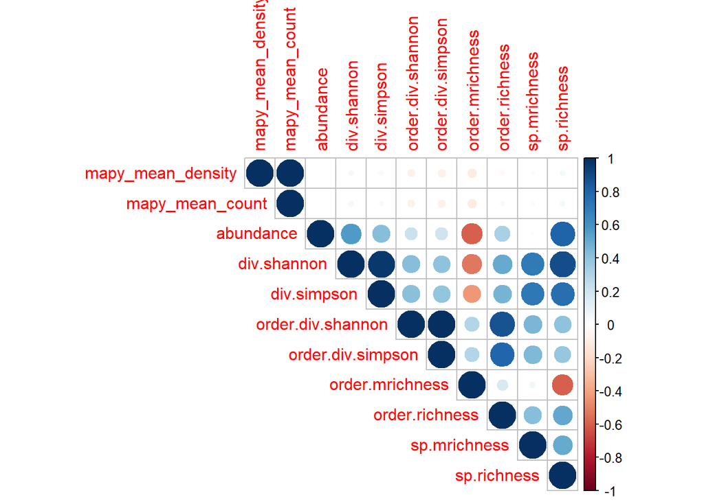

How does fish community abundance and diversity vary according to giant kelp size?

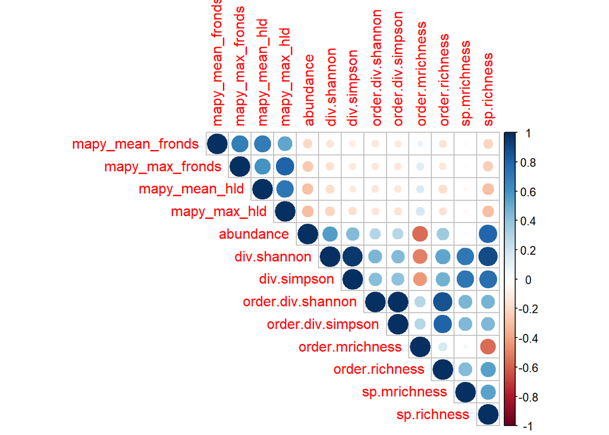

### Invertebrate Community Composition

How does invertebrate community abundance and diversity vary according to giant kelp abundance?

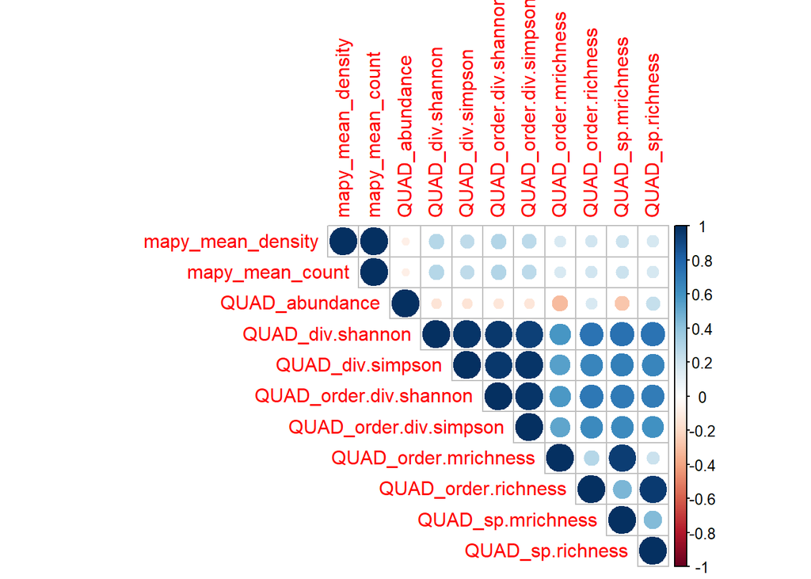

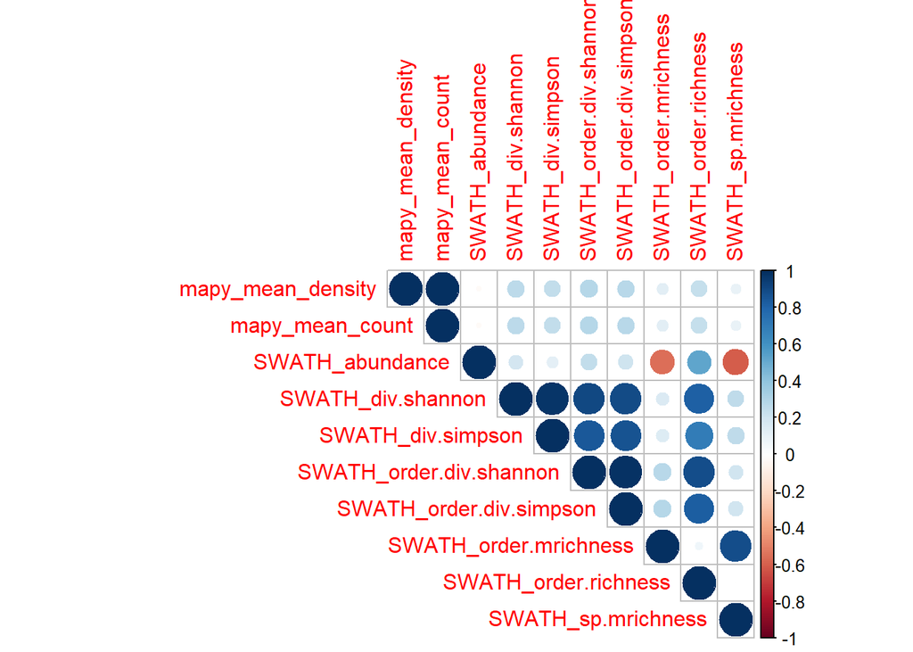

[figure not shown]

[figure not shown]

### Fish v. Invertebrate Communities

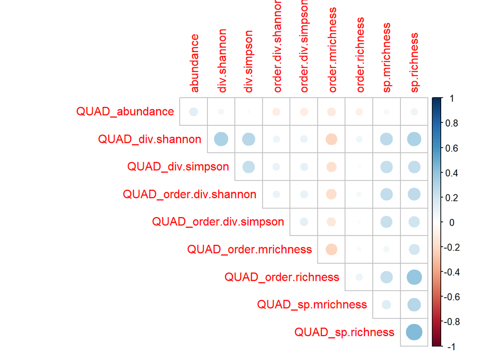

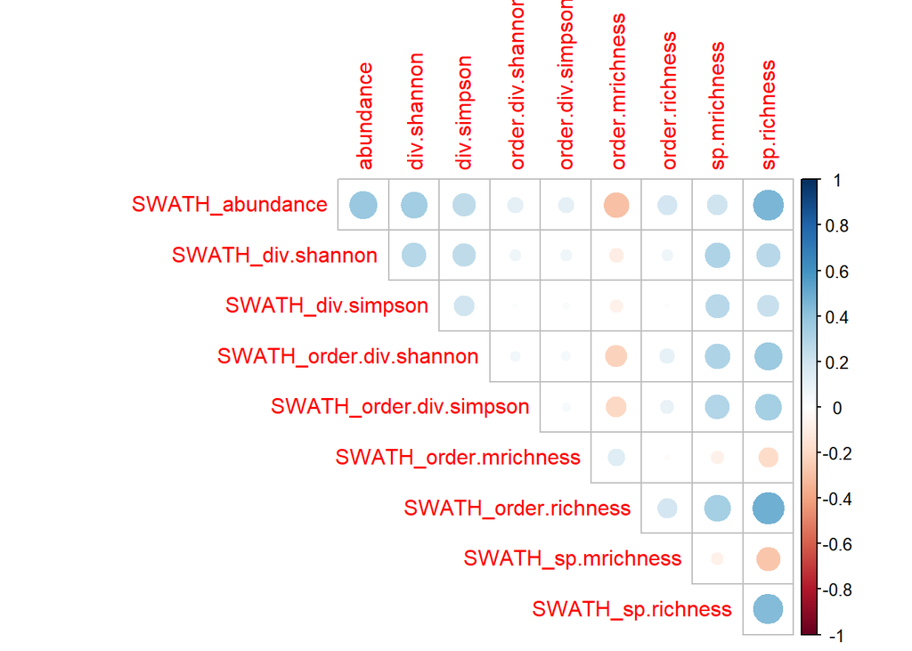

## Question 2

How does kelp size / abundance vary according to sea urchin density?

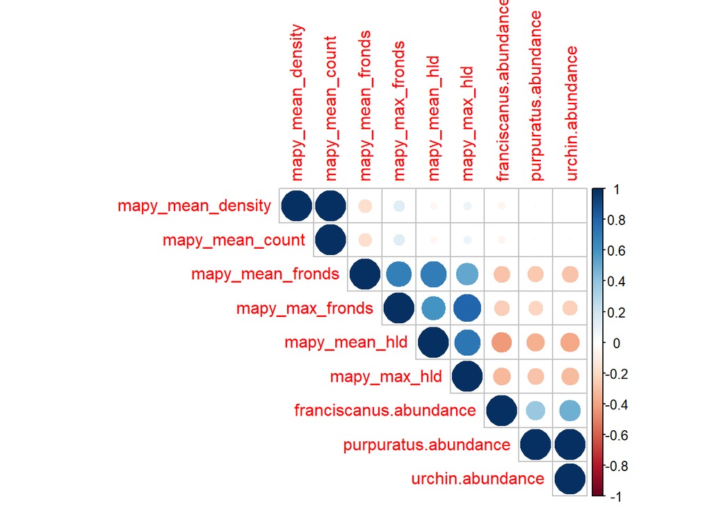

How does kelp size / abundance vary according to water chemistry?

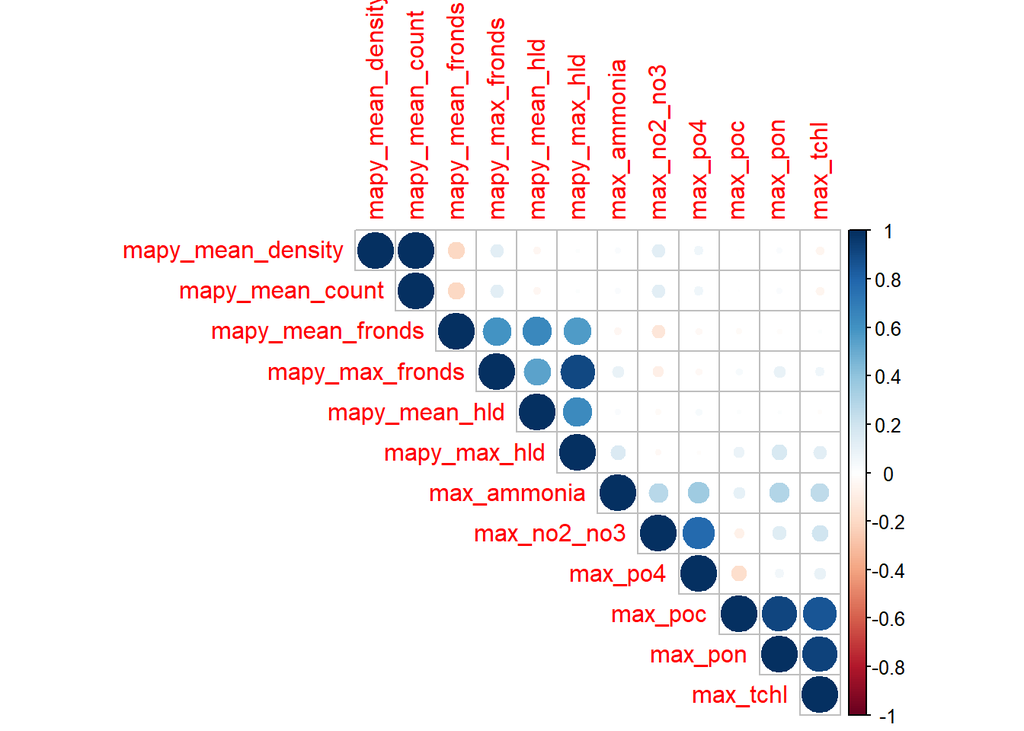

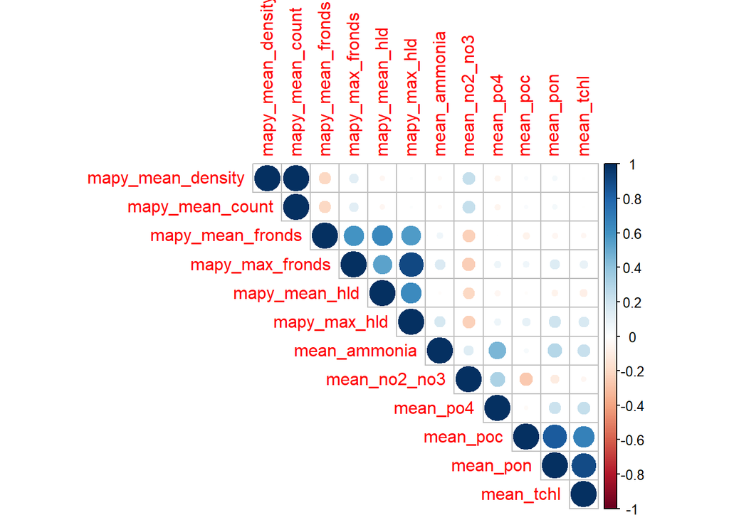

How does kelp size / abundance vary according to temperature?

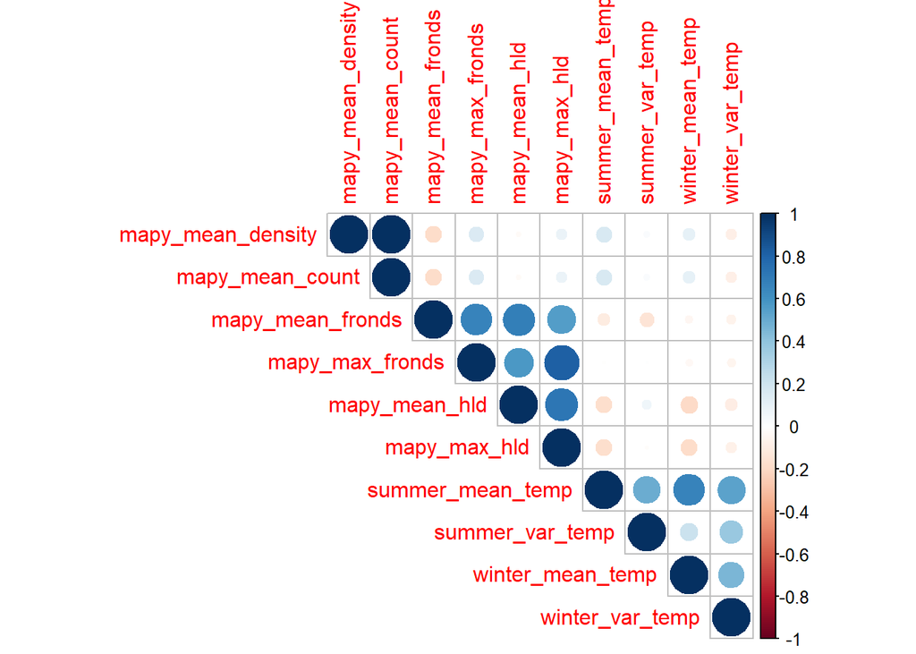